# Module 13

#### Hemi-module gene counts:

141 probesets in hemi-module A.  
104 probesets in hemi-module B.  
Note: While the mapping of probesets to genes is usually one-to-one, some genes are targeted by multiple probesets, some probesets target multiple genes, and some probesets do not target any genes (i.e., the region of the genome they match is no longer considered genic).

#### Contrast SVE:

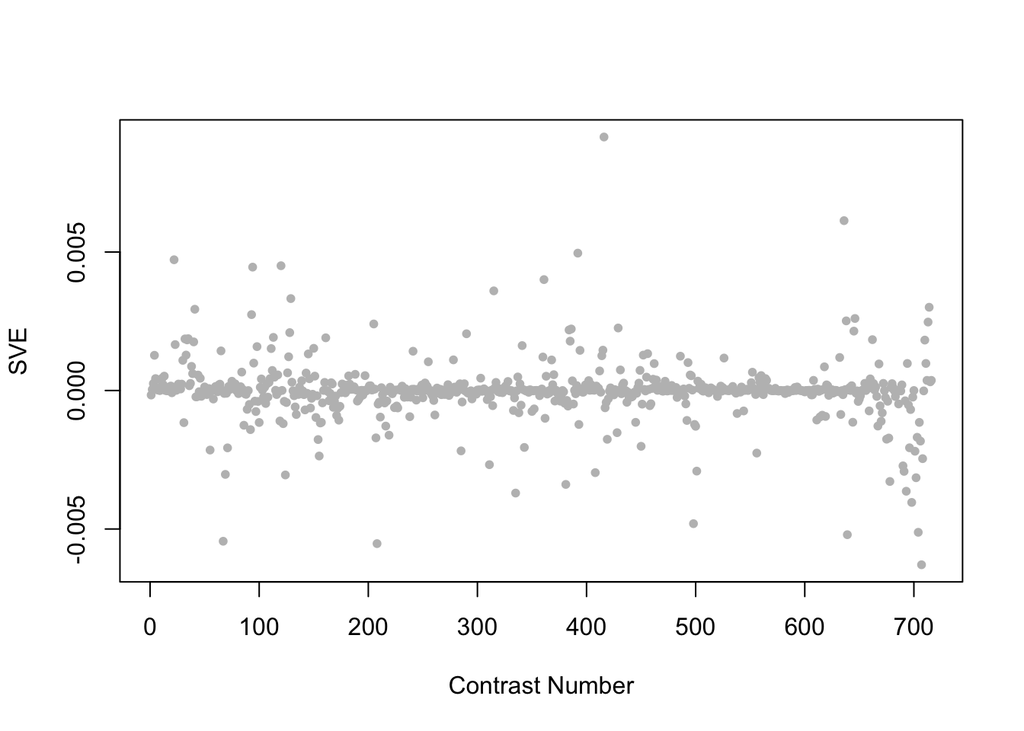

Positive SVE Contrasts:

|  | Contrast.Num | SVE | GEO.GSE | Cond.1 | Cond.2 | Mutation |
| --- | --- | --- | --- | --- | --- | --- |
| GSE29951.s0t2.vs.s0t1 | 416 | 0.01 | GSE29951 | C.elegans wild type raised in the presence of Cd, rep1 | C.elegans wild type raised in the absence of Cd, rep1 |  |
| GSE18132.s2t2.vs.s0t2 | 636 | 0.01 | GSE18132 | Oga Fed L4, biological replicate 1 | WT Fed L4, biological rep1 | oga-1 |
| GSE32339.s1t2.vs.s0t2 | 392 | 0.00 | GSE32339 | Adult Mutant, biological rep1 | Adult Wild-type, biological rep1 | nep-1 |
| GSE9665.s1t2.vs.s0t2 | 22 | 0.00 | GSE9665 | mex-3 elt-1 186 A | mex-3 186 A | elt-1 |
| GSE54024.s3t1.vs.s4t1 | 120 | 0.00 | GSE54024 | nuo-6(qm200) young adults, biological rep 1 | isp-1(qm150) young adults, biological rep 1 |  |

Negative SVE Contrasts:

|  | Contrast.Num | SVE | GEO.GSE | Cond.1 | Cond.2 | Mutation |
| --- | --- | --- | --- | --- | --- | --- |
| GSE11055.s1t7.vs.s1t1 | 707 | -0.01 | GSE11055 | L1-L2 larvae 15 hr after hatching in the presence of food | embryo 2 hr before hatching |  |
| GSE42703.s2t2.vs.s2t1 | 208 | -0.01 | GSE42703 | WT incubated with H2O, biological rep1 | WT incubated with 1mM copper sulfate, biological rep1 |  |
| GSE8659.s3t1.vs.s2t1 | 67 | -0.01 | GSE8659 | strain NL 2099 replicate 2 | strain GR1373 replicate 1 |  |
| GSE18132.s1t1.vs.s0t1 | 639 | -0.01 | GSE18132 | Ogt starved L1, biological replicate 1 | WT Starved L1, biological rep1 | ogt-1 |
| GSE11055.s1t6.vs.s1t1 | 704 | -0.01 | GSE11055 | L1 larvae 12 hr after hatching in the presence of food | embryo 2 hr before hatching |  |

$~$

#### Contrast SVE, Up-Regulated Genes Only:

Calculating SVE for up-regulated and down-regulated genes separately may be more informative in many cases than projecting the up- and down- gene sets together. This is due to the fact that the weight distribution of many modules is highly skewed, indicating that only one of the hemi-modules may be biologically meaningful (i.e., a set of genes are strongly correlated by only a few genes (or none) are strongly anti-correlated to that set.)

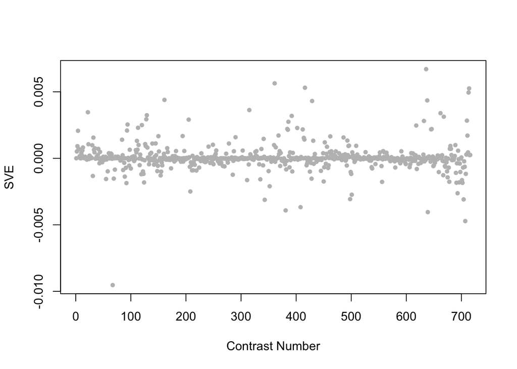

Positive SVE Contrasts:

|  | Contrast.Num | SVE | GEO.GSE | Cond.1 | Cond.2 | Mutation |
| --- | --- | --- | --- | --- | --- | --- |
| GSE18132.s2t2.vs.s0t2 | 636 | 0.01 | GSE18132 | Oga Fed L4, biological replicate 1 | WT Fed L4, biological rep1 | oga-1 |
| GSE37432.s2t1.vs.s0t1 | 361 | 0.01 | GSE37432 | piwi n4503 nDf57 rep1 | N2 rep1 | prg-1;prg-2 |
| GSE29951.s0t2.vs.s0t1 | 416 | 0.01 | GSE29951 | C.elegans wild type raised in the presence of Cd, rep1 | C.elegans wild type raised in the absence of Cd, rep1 |  |
| GSE11055.s2t5.vs.s2t2 | 714 | 0.01 | GSE11055 | L1 larvae 6 hr after hatching in the absence of food | L1 larvae 0 hr after hatching in the absence of food |  |
| GSE11055.s2t4.vs.s2t2 | 713 | 0.00 | GSE11055 | L1 larvae 3 hr after hatching in the absence of food | L1 larvae 0 hr after hatching in the absence of food |  |

Negative SVE Contrasts:

|  | Contrast.Num | SVE | GEO.GSE | Cond.1 | Cond.2 | Mutation |
| --- | --- | --- | --- | --- | --- | --- |
| GSE8659.s3t1.vs.s2t1 | 67 | -0.01 | GSE8659 | strain NL 2099 replicate 2 | strain GR1373 replicate 1 |  |
| GSE11055.s1t7.vs.s1t1 | 707 | -0.00 | GSE11055 | L1-L2 larvae 15 hr after hatching in the presence of food | embryo 2 hr before hatching |  |
| GSE18132.s1t1.vs.s0t1 | 639 | -0.00 | GSE18132 | Ogt starved L1, biological replicate 1 | WT Starved L1, biological rep1 | ogt-1 |
| GSE34471.s0t2.vs.s0t1 | 381 | -0.00 | GSE34471 | 20uM-Con-1 | 4uM-Con-1 |  |
| GSE30505.s1t1.vs.s2t1 | 408 | -0.00 | GSE30505 | L3 N2 (WT) E.V. #1 | L3 N2 (WT) ash-2 #1 | ash-2 |

$~$

#### Contrast SVE, Down-Regulated Genes Only:

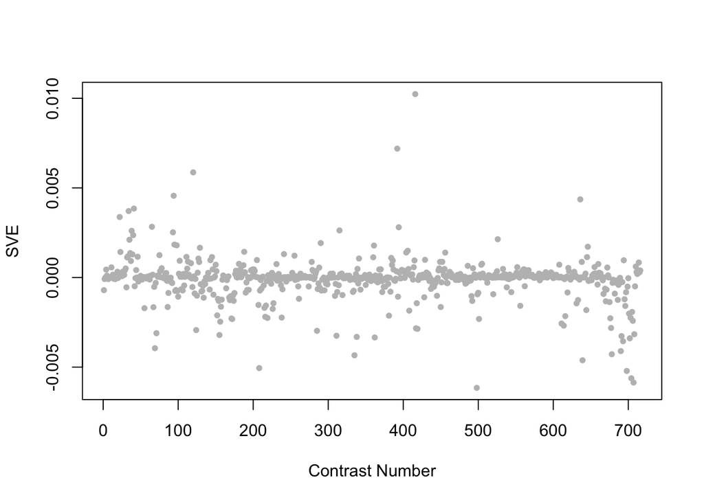

Positive SVE Contrasts:

|  | Contrast.Num | SVE | GEO.GSE | Cond.1 | Cond.2 | Mutation |
| --- | --- | --- | --- | --- | --- | --- |
| GSE29951.s0t2.vs.s0t1 | 416 | 0.01 | GSE29951 | C.elegans wild type raised in the presence of Cd, rep1 | C.elegans wild type raised in the absence of Cd, rep1 |  |
| GSE32339.s1t2.vs.s0t2 | 392 | 0.01 | GSE32339 | Adult Mutant, biological rep1 | Adult Wild-type, biological rep1 | nep-1 |
| GSE54024.s3t1.vs.s4t1 | 120 | 0.01 | GSE54024 | nuo-6(qm200) young adults, biological rep 1 | isp-1(qm150) young adults, biological rep 1 |  |
| GSE5801.s3t1.vs.s2t1 | 94 | 0.00 | GSE5801 | daf2pmk1_RepA | daf2daf16_RepA |  |
| GSE18132.s2t2.vs.s0t2 | 636 | 0.00 | GSE18132 | Oga Fed L4, biological replicate 1 | WT Fed L4, biological rep1 | oga-1 |

Negative SVE Contrasts:

|  | Contrast.Num | SVE | GEO.GSE | Cond.1 | Cond.2 | Mutation |
| --- | --- | --- | --- | --- | --- | --- |
| GSE23013.s4t1.vs.s0t1 | 498 | -0.01 | GSE23013 | young adult_24hr Benzene exposure_rep1 | young adult_not exposed_rep1 |  |
| GSE11055.s1t7.vs.s1t1 | 707 | -0.01 | GSE11055 | L1-L2 larvae 15 hr after hatching in the presence of food | embryo 2 hr before hatching |  |
| GSE11055.s1t6.vs.s1t1 | 704 | -0.01 | GSE11055 | L1 larvae 12 hr after hatching in the presence of food | embryo 2 hr before hatching |  |
| GSE11055.s3t4.vs.s2t4 | 698 | -0.01 | GSE11055 | L1 larvae 3 hr after hatching in the absence of food in the alternative starvation buffer M9 | L1 larvae 3 hr after hatching in the absence of food |  |
| GSE42703.s2t2.vs.s2t1 | 208 | -0.01 | GSE42703 | WT incubated with H2O, biological rep1 | WT incubated with 1mM copper sulfate, biological rep1 |  |

$~$

$~$

#### GO Term Enrichment:

This analysis tests each hemi-module for enrichment of specific GO terms. Only gene-level annotations (e.g., as would be found on the gene’s page in Wormbase) are tested - the hierarchical structure of the GO ontology is not taken into account.

*Note: At least the top two most enriched terms from each GO domain (BP/MF/CC) are shown, even when not statistically significant.*

##### Enriched GO terms: Hemi-module A

| ID | GO.Term | GO Domain | Raw p-value | Adj p-value |
| --- | --- | --- | --- | --- |
| [GO_0007617](http://amigo.geneontology.org/amigo/term/GO:0007617) | mating behavior | BP | 2.87e-05 | 1.05e-01 |
| [GO_0023041](http://amigo.geneontology.org/amigo/term/GO:0023041) | neuronal signal transduction | BP | 4.98e-04 | 9.07e-01 |
| [GO_0044325](http://amigo.geneontology.org/amigo/term/GO:0044325) | ion channel binding | MF | 5.05e-05 | 1.03e-01 |
| [GO_0015278](http://amigo.geneontology.org/amigo/term/GO:0015278) | calcium-release channel activity | MF | 7.15e-03 | 9.99e-01 |
| [GO_0016020](http://amigo.geneontology.org/amigo/term/GO:0016020) | membrane | CC | 4.92e-05 | 4.56e-02 |
| [GO_0016021](http://amigo.geneontology.org/amigo/term/GO:0016021) | integral component of membrane | CC | 4.89e-04 | 2.27e-01 |

##### Enriched GO terms: Hemi-module B

| ID | GO.Term | GO Domain | Raw p-value | Adj p-value |
| --- | --- | --- | --- | --- |
| [GO_0018149](http://amigo.geneontology.org/amigo/term/GO:0018149) | peptide cross-linking | BP | 8.86e-05 | 3.23e-01 |
| [GO_0098869](http://amigo.geneontology.org/amigo/term/GO:0098869) | cellular oxidant detoxification | BP | 1.35e-03 | 9.98e-01 |
| [GO_0004831](http://amigo.geneontology.org/amigo/term/GO:0004831) | tyrosine-tRNA ligase activity | MF | 5.49e-03 | 1.00e+00 |
| [GO_0005006](http://amigo.geneontology.org/amigo/term/GO:0005006) | epidermal growth factor-activated receptor activity | MF | 5.49e-03 | 1.00e+00 |
| [GO_0005911](http://amigo.geneontology.org/amigo/term/GO:0005911) | cell-cell junction | CC | 4.77e-03 | 9.99e-01 |
| [GO_0043196](http://amigo.geneontology.org/amigo/term/GO:0043196) | varicosity | CC | 5.49e-03 | 9.99e-01 |

$~$

$~$

#### Tissue Enrichment:

This analysis tests each hemi-module for enrichment of genes associated with anatomy terms. Negative enrichment scores indicate fewer hemi-module genes than expected by random chance were associated with the anatomy term in question.

##### Enriched tissues: Hemi-module A

No significant annotations.

##### Enriched tissues: Hemi-module B

No significant annotations.

$~$

$~$

#### HOMER promoter motif enrichment:

This analysis tests each hemi-module for enrichment of 108 known *C. elegans* transcription factor binding site motifs (see [108 CE motifs](https://katiepod.github.io//all.worm.motifs.html)) using the HOMER (Hypergeometric Optimization of Motif EnRichment) software (see [PMID:20513432](https://pubmed.ncbi.nlm.nih.gov/20513432)). HOMER was run using default parameters on sequences 1 kb upstream of the transcription start site.

##### Motif enrichment: Hemi-module A

Total target sequences = 110  
Total background sequences = 39671  
* - possible false positive

Rank

Motif

P-value

log P-pvalue

% of Targets

% of Background

STD(Bg STD)

Best Match/Details

Motif File

1 *

[figure not shown]

1e-10

-2.331e+01

10.91%

0.76%

183.6bp (323.2bp)

POL004.1_CCAAT-box/Jaspar(0.529)  
[More Information](https://katiepod.github.io/HomerResults/m13_a_hemi_genes.txt.out.1kb/homerResults/motif1.info.html) | [Similar Motifs Found](https://katiepod.github.io/HomerResults/m13_a_hemi_genes.txt.out.1kb/homerResults/motif1.similar.html)

[motif file (matrix)](https://katiepod.github.io/HomerResults/m13_a_hemi_genes.txt.out.1kb/homerResults/motif1.motif)

2 *

[figure not shown]

1e-9

-2.084e+01

12.73%

1.43%

220.2bp (302.3bp)

POL008.1_DCE_S_I/Jaspar(0.578)  
[More Information](https://katiepod.github.io/HomerResults/m13_a_hemi_genes.txt.out.1kb/homerResults/motif2.info.html) | [Similar Motifs Found](https://katiepod.github.io/HomerResults/m13_a_hemi_genes.txt.out.1kb/homerResults/motif2.similar.html)

[motif file (matrix)](https://katiepod.github.io/HomerResults/m13_a_hemi_genes.txt.out.1kb/homerResults/motif2.motif)

3 *

[figure not shown]

1e-8

-2.031e+01

11.82%

1.23%

220.5bp (281.6bp)

pal-1/MA0924.1/Jaspar(0.592)  
[More Information](https://katiepod.github.io/HomerResults/m13_a_hemi_genes.txt.out.1kb/homerResults/motif3.info.html) | [Similar Motifs Found](https://katiepod.github.io/HomerResults/m13_a_hemi_genes.txt.out.1kb/homerResults/motif3.similar.html)

[motif file (matrix)](https://katiepod.github.io/HomerResults/m13_a_hemi_genes.txt.out.1kb/homerResults/motif3.motif)

4 *

[figure not shown]

1e-8

-1.981e+01

13.64%

1.84%

293.2bp (348.9bp)

efl-1/MA0541.1/Jaspar(0.483)  
[More Information](https://katiepod.github.io/HomerResults/m13_a_hemi_genes.txt.out.1kb/homerResults/motif4.info.html) | [Similar Motifs Found](https://katiepod.github.io/HomerResults/m13_a_hemi_genes.txt.out.1kb/homerResults/motif4.similar.html)

[motif file (matrix)](https://katiepod.github.io/HomerResults/m13_a_hemi_genes.txt.out.1kb/homerResults/motif4.motif)

5 *

[figure not shown]

1e-8

-1.936e+01

11.82%

1.34%

263.4bp (300.0bp)

che-1/MA0260.1/Jaspar(0.635)  
[More Information](https://katiepod.github.io/HomerResults/m13_a_hemi_genes.txt.out.1kb/homerResults/motif5.info.html) | [Similar Motifs Found](https://katiepod.github.io/HomerResults/m13_a_hemi_genes.txt.out.1kb/homerResults/motif5.similar.html)

[motif file (matrix)](https://katiepod.github.io/HomerResults/m13_a_hemi_genes.txt.out.1kb/homerResults/motif5.motif)

6 *

[figure not shown]

1e-7

-1.840e+01

6.36%

0.23%

206.8bp (289.8bp)

che-1/MA0260.1/Jaspar(0.549)  
[More Information](https://katiepod.github.io/HomerResults/m13_a_hemi_genes.txt.out.1kb/homerResults/motif6.info.html) | [Similar Motifs Found](https://katiepod.github.io/HomerResults/m13_a_hemi_genes.txt.out.1kb/homerResults/motif6.similar.html)

[motif file (matrix)](https://katiepod.github.io/HomerResults/m13_a_hemi_genes.txt.out.1kb/homerResults/motif6.motif)

7 *

[figure not shown]

1e-7

-1.786e+01

7.27%

0.39%

283.2bp (335.0bp)

POL011.1_XCPE1/Jaspar(0.536)  
[More Information](https://katiepod.github.io/HomerResults/m13_a_hemi_genes.txt.out.1kb/homerResults/motif7.info.html) | [Similar Motifs Found](https://katiepod.github.io/HomerResults/m13_a_hemi_genes.txt.out.1kb/homerResults/motif7.similar.html)

[motif file (matrix)](https://katiepod.github.io/HomerResults/m13_a_hemi_genes.txt.out.1kb/homerResults/motif7.motif)

8 *

[figure not shown]

1e-7

-1.781e+01

5.45%

0.14%

256.9bp (285.4bp)

ces-2/MA0922.1/Jaspar(0.503)  
[More Information](https://katiepod.github.io/HomerResults/m13_a_hemi_genes.txt.out.1kb/homerResults/motif8.info.html) | [Similar Motifs Found](https://katiepod.github.io/HomerResults/m13_a_hemi_genes.txt.out.1kb/homerResults/motif8.similar.html)

[motif file (matrix)](https://katiepod.github.io/HomerResults/m13_a_hemi_genes.txt.out.1kb/homerResults/motif8.motif)

9 *

[figure not shown]

1e-7

-1.765e+01

11.82%

1.55%

257.6bp (313.2bp)

POL008.1_DCE_S_I/Jaspar(0.707)  
[More Information](https://katiepod.github.io/HomerResults/m13_a_hemi_genes.txt.out.1kb/homerResults/motif9.info.html) | [Similar Motifs Found](https://katiepod.github.io/HomerResults/m13_a_hemi_genes.txt.out.1kb/homerResults/motif9.similar.html)

[motif file (matrix)](https://katiepod.github.io/HomerResults/m13_a_hemi_genes.txt.out.1kb/homerResults/motif9.motif)

10 *

[figure not shown]

1e-7

-1.731e+01

10.91%

1.31%

244.4bp (297.8bp)

eor-1/MA0543.1/Jaspar(0.558)  
[More Information](https://katiepod.github.io/HomerResults/m13_a_hemi_genes.txt.out.1kb/homerResults/motif10.info.html) | [Similar Motifs Found](https://katiepod.github.io/HomerResults/m13_a_hemi_genes.txt.out.1kb/homerResults/motif10.similar.html)

[motif file (matrix)](https://katiepod.github.io/HomerResults/m13_a_hemi_genes.txt.out.1kb/homerResults/motif10.motif)

11 *

[figure not shown]

1e-7

-1.690e+01

11.82%

1.65%

221.9bp (313.7bp)

ELT-3(Gata)/cElegans-L1-ELT3-ChIP-Seq(modEncode)/Homer(0.582)  
[More Information](https://katiepod.github.io/HomerResults/m13_a_hemi_genes.txt.out.1kb/homerResults/motif11.info.html) | [Similar Motifs Found](https://katiepod.github.io/HomerResults/m13_a_hemi_genes.txt.out.1kb/homerResults/motif11.similar.html)

[motif file (matrix)](https://katiepod.github.io/HomerResults/m13_a_hemi_genes.txt.out.1kb/homerResults/motif11.motif)

12 *

[figure not shown]

1e-7

-1.645e+01

3.64%

0.03%

100.5bp (392.7bp)

PL0005.1_hlh-30/Jaspar(0.640)  
[More Information](https://katiepod.github.io/HomerResults/m13_a_hemi_genes.txt.out.1kb/homerResults/motif12.info.html) | [Similar Motifs Found](https://katiepod.github.io/HomerResults/m13_a_hemi_genes.txt.out.1kb/homerResults/motif12.similar.html)

[motif file (matrix)](https://katiepod.github.io/HomerResults/m13_a_hemi_genes.txt.out.1kb/homerResults/motif12.motif)

13 *

[figure not shown]

1e-6

-1.553e+01

15.45%

3.35%

259.4bp (300.6bp)

mab-3/MA0262.1/Jaspar(0.655)  
[More Information](https://katiepod.github.io/HomerResults/m13_a_hemi_genes.txt.out.1kb/homerResults/motif13.info.html) | [Similar Motifs Found](https://katiepod.github.io/HomerResults/m13_a_hemi_genes.txt.out.1kb/homerResults/motif13.similar.html)

[motif file (matrix)](https://katiepod.github.io/HomerResults/m13_a_hemi_genes.txt.out.1kb/homerResults/motif13.motif)

14 *

[figure not shown]

1e-6

-1.408e+01

3.64%

0.06%

154.0bp (265.6bp)

snpc-4/MA0544.1/Jaspar(0.556)  
[More Information](https://katiepod.github.io/HomerResults/m13_a_hemi_genes.txt.out.1kb/homerResults/motif14.info.html) | [Similar Motifs Found](https://katiepod.github.io/HomerResults/m13_a_hemi_genes.txt.out.1kb/homerResults/motif14.similar.html)

[motif file (matrix)](https://katiepod.github.io/HomerResults/m13_a_hemi_genes.txt.out.1kb/homerResults/motif14.motif)

15 *

[figure not shown]

1e-5

-1.370e+01

2.73%

0.01%

299.7bp (231.8bp)

MF0003.1_REL_class/Jaspar(0.656)  
[More Information](https://katiepod.github.io/HomerResults/m13_a_hemi_genes.txt.out.1kb/homerResults/motif15.info.html) | [Similar Motifs Found](https://katiepod.github.io/HomerResults/m13_a_hemi_genes.txt.out.1kb/homerResults/motif15.similar.html)

[motif file (matrix)](https://katiepod.github.io/HomerResults/m13_a_hemi_genes.txt.out.1kb/homerResults/motif15.motif)

16 *

[figure not shown]

1e-5

-1.359e+01

20.91%

6.80%

256.9bp (315.7bp)

PL0015.1_hlh-2::hlh-14/Jaspar(0.541)  
[More Information](https://katiepod.github.io/HomerResults/m13_a_hemi_genes.txt.out.1kb/homerResults/motif16.info.html) | [Similar Motifs Found](https://katiepod.github.io/HomerResults/m13_a_hemi_genes.txt.out.1kb/homerResults/motif16.similar.html)

[motif file (matrix)](https://katiepod.github.io/HomerResults/m13_a_hemi_genes.txt.out.1kb/homerResults/motif16.motif)

17 *

[figure not shown]

1e-5

-1.294e+01

2.73%

0.02%

259.5bp (385.4bp)

POL011.1_XCPE1/Jaspar(0.744)  
[More Information](https://katiepod.github.io/HomerResults/m13_a_hemi_genes.txt.out.1kb/homerResults/motif17.info.html) | [Similar Motifs Found](https://katiepod.github.io/HomerResults/m13_a_hemi_genes.txt.out.1kb/homerResults/motif17.similar.html)

[motif file (matrix)](https://katiepod.github.io/HomerResults/m13_a_hemi_genes.txt.out.1kb/homerResults/motif17.motif)

18 *

[figure not shown]

1e-5

-1.250e+01

22.73%

8.37%

287.9bp (298.9bp)

mab-5/MA1442.1/Jaspar(0.786)  
[More Information](https://katiepod.github.io/HomerResults/m13_a_hemi_genes.txt.out.1kb/homerResults/motif18.info.html) | [Similar Motifs Found](https://katiepod.github.io/HomerResults/m13_a_hemi_genes.txt.out.1kb/homerResults/motif18.similar.html)

[motif file (matrix)](https://katiepod.github.io/HomerResults/m13_a_hemi_genes.txt.out.1kb/homerResults/motif18.motif)

19 *

[figure not shown]

1e-5

-1.191e+01

3.64%

0.10%

84.0bp (245.1bp)

lin-54/MA1450.1/Jaspar(0.714)  
[More Information](https://katiepod.github.io/HomerResults/m13_a_hemi_genes.txt.out.1kb/homerResults/motif19.info.html) | [Similar Motifs Found](https://katiepod.github.io/HomerResults/m13_a_hemi_genes.txt.out.1kb/homerResults/motif19.similar.html)

[motif file (matrix)](https://katiepod.github.io/HomerResults/m13_a_hemi_genes.txt.out.1kb/homerResults/motif19.motif)

20 *

[figure not shown]

1e-5

-1.174e+01

7.27%

0.89%

262.0bp (296.1bp)

cebp-1/MA1444.1/Jaspar(0.578)  
[More Information](https://katiepod.github.io/HomerResults/m13_a_hemi_genes.txt.out.1kb/homerResults/motif20.info.html) | [Similar Motifs Found](https://katiepod.github.io/HomerResults/m13_a_hemi_genes.txt.out.1kb/homerResults/motif20.similar.html)

[motif file (matrix)](https://katiepod.github.io/HomerResults/m13_a_hemi_genes.txt.out.1kb/homerResults/motif20.motif)

21 *

[figure not shown]

1e-4

-1.085e+01

18.18%

6.34%

286.6bp (320.0bp)

MF0004.1_Nuclear_Receptor_class/Jaspar(0.601)  
[More Information](https://katiepod.github.io/HomerResults/m13_a_hemi_genes.txt.out.1kb/homerResults/motif21.info.html) | [Similar Motifs Found](https://katiepod.github.io/HomerResults/m13_a_hemi_genes.txt.out.1kb/homerResults/motif21.similar.html)

[motif file (matrix)](https://katiepod.github.io/HomerResults/m13_a_hemi_genes.txt.out.1kb/homerResults/motif21.motif)

22 *

[figure not shown]

1e-4

-1.071e+01

1.82%

0.00%

28.0bp (0.0bp)

PL0002.1_hlh-2::hlh-3/Jaspar(0.487)  
[More Information](https://katiepod.github.io/HomerResults/m13_a_hemi_genes.txt.out.1kb/homerResults/motif22.info.html) | [Similar Motifs Found](https://katiepod.github.io/HomerResults/m13_a_hemi_genes.txt.out.1kb/homerResults/motif22.similar.html)

[motif file (matrix)](https://katiepod.github.io/HomerResults/m13_a_hemi_genes.txt.out.1kb/homerResults/motif22.motif)

23 *

[figure not shown]

1e-4

-1.042e+01

2.73%

0.05%

315.2bp (236.5bp)

unc-86/MA0926.1/Jaspar(0.650)  
[More Information](https://katiepod.github.io/HomerResults/m13_a_hemi_genes.txt.out.1kb/homerResults/motif23.info.html) | [Similar Motifs Found](https://katiepod.github.io/HomerResults/m13_a_hemi_genes.txt.out.1kb/homerResults/motif23.similar.html)

[motif file (matrix)](https://katiepod.github.io/HomerResults/m13_a_hemi_genes.txt.out.1kb/homerResults/motif23.motif)

24 *

[figure not shown]

1e-4

-1.027e+01

4.55%

0.32%

230.6bp (332.3bp)

PL0002.1_hlh-2::hlh-3/Jaspar(0.572)  
[More Information](https://katiepod.github.io/HomerResults/m13_a_hemi_genes.txt.out.1kb/homerResults/motif24.info.html) | [Similar Motifs Found](https://katiepod.github.io/HomerResults/m13_a_hemi_genes.txt.out.1kb/homerResults/motif24.similar.html)

[motif file (matrix)](https://katiepod.github.io/HomerResults/m13_a_hemi_genes.txt.out.1kb/homerResults/motif24.motif)

25 *

[figure not shown]

1e-4

-1.002e+01

2.73%

0.06%

206.9bp (323.7bp)

POL012.1_TATA-Box/Jaspar(0.577)  
[More Information](https://katiepod.github.io/HomerResults/m13_a_hemi_genes.txt.out.1kb/homerResults/motif25.info.html) | [Similar Motifs Found](https://katiepod.github.io/HomerResults/m13_a_hemi_genes.txt.out.1kb/homerResults/motif25.similar.html)

[motif file (matrix)](https://katiepod.github.io/HomerResults/m13_a_hemi_genes.txt.out.1kb/homerResults/motif25.motif)

26 *

[figure not shown]

1e-4

-9.781e+00

3.64%

0.18%

220.7bp (252.2bp)

PL0003.1_hlh-2::cnd-1/Jaspar(0.615)  
[More Information](https://katiepod.github.io/HomerResults/m13_a_hemi_genes.txt.out.1kb/homerResults/motif26.info.html) | [Similar Motifs Found](https://katiepod.github.io/HomerResults/m13_a_hemi_genes.txt.out.1kb/homerResults/motif26.similar.html)

[motif file (matrix)](https://katiepod.github.io/HomerResults/m13_a_hemi_genes.txt.out.1kb/homerResults/motif26.motif)

27 *

[figure not shown]

1e-4

-9.751e+00

17.27%

6.30%

257.1bp (300.6bp)

MF0006.1_bZIP_cEBP-like_subclass/Jaspar(0.599)  
[More Information](https://katiepod.github.io/HomerResults/m13_a_hemi_genes.txt.out.1kb/homerResults/motif27.info.html) | [Similar Motifs Found](https://katiepod.github.io/HomerResults/m13_a_hemi_genes.txt.out.1kb/homerResults/motif27.similar.html)

[motif file (matrix)](https://katiepod.github.io/HomerResults/m13_a_hemi_genes.txt.out.1kb/homerResults/motif27.motif)

28 *

[figure not shown]

1e-3

-9.130e+00

4.55%

0.41%

309.7bp (326.4bp)

POL013.1_MED-1/Jaspar(0.566)  
[More Information](https://katiepod.github.io/HomerResults/m13_a_hemi_genes.txt.out.1kb/homerResults/motif28.info.html) | [Similar Motifs Found](https://katiepod.github.io/HomerResults/m13_a_hemi_genes.txt.out.1kb/homerResults/motif28.similar.html)

[motif file (matrix)](https://katiepod.github.io/HomerResults/m13_a_hemi_genes.txt.out.1kb/homerResults/motif28.motif)

29 *

[figure not shown]

1e-3

-8.767e+00

1.82%

0.01%

178.8bp (216.2bp)

PL0008.1_hlh-29/Jaspar(0.574)  
[More Information](https://katiepod.github.io/HomerResults/m13_a_hemi_genes.txt.out.1kb/homerResults/motif29.info.html) | [Similar Motifs Found](https://katiepod.github.io/HomerResults/m13_a_hemi_genes.txt.out.1kb/homerResults/motif29.similar.html)

[motif file (matrix)](https://katiepod.github.io/HomerResults/m13_a_hemi_genes.txt.out.1kb/homerResults/motif29.motif)

30 *

[figure not shown]

1e-3

-8.481e+00

1.82%

0.02%

153.0bp (265.7bp)

ceh-22/MA0264.1/Jaspar(0.476)  
[More Information](https://katiepod.github.io/HomerResults/m13_a_hemi_genes.txt.out.1kb/homerResults/motif30.info.html) | [Similar Motifs Found](https://katiepod.github.io/HomerResults/m13_a_hemi_genes.txt.out.1kb/homerResults/motif30.similar.html)

[motif file (matrix)](https://katiepod.github.io/HomerResults/m13_a_hemi_genes.txt.out.1kb/homerResults/motif30.motif)

31 *

[figure not shown]

1e-2

-6.033e+00

5.45%

1.22%

257.3bp (327.9bp)

LIN-39(Homeobox)/cElegans.L3-LIN39-ChIP-Seq(modEncode)/Homer(0.586)  
[More Information](https://katiepod.github.io/HomerResults/m13_a_hemi_genes.txt.out.1kb/homerResults/motif31.info.html) | [Similar Motifs Found](https://katiepod.github.io/HomerResults/m13_a_hemi_genes.txt.out.1kb/homerResults/motif31.similar.html)

[motif file (matrix)](https://katiepod.github.io/HomerResults/m13_a_hemi_genes.txt.out.1kb/homerResults/motif31.motif)

32 *

[figure not shown]

1e-2

-5.777e+00

1.82%

0.07%

192.3bp (280.4bp)

ceh-10::ttx-3/MA0263.1/Jaspar(0.549)  
[More Information](https://katiepod.github.io/HomerResults/m13_a_hemi_genes.txt.out.1kb/homerResults/motif32.info.html) | [Similar Motifs Found](https://katiepod.github.io/HomerResults/m13_a_hemi_genes.txt.out.1kb/homerResults/motif32.similar.html)

[motif file (matrix)](https://katiepod.github.io/HomerResults/m13_a_hemi_genes.txt.out.1kb/homerResults/motif32.motif)

33 *

[figure not shown]

1e-2

-4.801e+00

0.91%

0.01%

82.2bp (390.2bp)

PL0019.1_hlh-1/Jaspar(0.616)  
[More Information](https://katiepod.github.io/HomerResults/m13_a_hemi_genes.txt.out.1kb/homerResults/motif33.info.html) | [Similar Motifs Found](https://katiepod.github.io/HomerResults/m13_a_hemi_genes.txt.out.1kb/homerResults/motif33.similar.html)

[motif file (matrix)](https://katiepod.github.io/HomerResults/m13_a_hemi_genes.txt.out.1kb/homerResults/motif33.motif)

34 *

[figure not shown]

1e-1

-4.292e+00

0.91%

0.01%

0.0bp (235.7bp)

sma-4/MA0925.1/Jaspar(0.586)  
[More Information](https://katiepod.github.io/HomerResults/m13_a_hemi_genes.txt.out.1kb/homerResults/motif34.info.html) | [Similar Motifs Found](https://katiepod.github.io/HomerResults/m13_a_hemi_genes.txt.out.1kb/homerResults/motif34.similar.html)

[motif file (matrix)](https://katiepod.github.io/HomerResults/m13_a_hemi_genes.txt.out.1kb/homerResults/motif34.motif)

##### Motif enrichment: Hemi-module B

Total target sequences = 92  
Total background sequences = 39817  
* - possible false positive

Rank

Motif

P-value

log P-pvalue

% of Targets

% of Background

STD(Bg STD)

Best Match/Details

Motif File

1 *

[figure not shown]

1e-11

-2.579e+01

19.57%

2.35%

264.8bp (306.6bp)

fkh-9/MA1440.1/Jaspar(0.569)  
[More Information](https://katiepod.github.io/HomerResults/m13_b_hemi_genes.txt.out.1kb/homerResults/motif1.info.html) | [Similar Motifs Found](https://katiepod.github.io/HomerResults/m13_b_hemi_genes.txt.out.1kb/homerResults/motif1.similar.html)

[motif file (matrix)](https://katiepod.github.io/HomerResults/m13_b_hemi_genes.txt.out.1kb/homerResults/motif1.motif)

2 *

[figure not shown]

1e-10

-2.441e+01

18.48%

2.22%

251.4bp (283.3bp)

MF0010.1_Homeobox_class/Jaspar(0.655)  
[More Information](https://katiepod.github.io/HomerResults/m13_b_hemi_genes.txt.out.1kb/homerResults/motif2.info.html) | [Similar Motifs Found](https://katiepod.github.io/HomerResults/m13_b_hemi_genes.txt.out.1kb/homerResults/motif2.similar.html)

[motif file (matrix)](https://katiepod.github.io/HomerResults/m13_b_hemi_genes.txt.out.1kb/homerResults/motif2.motif)

3 *

[figure not shown]

1e-9

-2.208e+01

5.43%

0.03%

197.1bp (199.9bp)

daf-16/MA1446.1/Jaspar(0.539)  
[More Information](https://katiepod.github.io/HomerResults/m13_b_hemi_genes.txt.out.1kb/homerResults/motif3.info.html) | [Similar Motifs Found](https://katiepod.github.io/HomerResults/m13_b_hemi_genes.txt.out.1kb/homerResults/motif3.similar.html)

[motif file (matrix)](https://katiepod.github.io/HomerResults/m13_b_hemi_genes.txt.out.1kb/homerResults/motif3.motif)

4 *

[figure not shown]

1e-9

-2.177e+01

10.87%

0.60%

305.8bp (283.4bp)

DPL-1(E2F)/cElegans-Adult-ChIP-Seq(modEncode)/Homer(0.587)  
[More Information](https://katiepod.github.io/HomerResults/m13_b_hemi_genes.txt.out.1kb/homerResults/motif4.info.html) | [Similar Motifs Found](https://katiepod.github.io/HomerResults/m13_b_hemi_genes.txt.out.1kb/homerResults/motif4.similar.html)

[motif file (matrix)](https://katiepod.github.io/HomerResults/m13_b_hemi_genes.txt.out.1kb/homerResults/motif4.motif)

5 *

[figure not shown]

1e-8

-2.055e+01

5.43%

0.04%

170.4bp (258.2bp)

LIN-39(Homeobox)/cElegans.L3-LIN39-ChIP-Seq(modEncode)/Homer(0.716)  
[More Information](https://katiepod.github.io/HomerResults/m13_b_hemi_genes.txt.out.1kb/homerResults/motif5.info.html) | [Similar Motifs Found](https://katiepod.github.io/HomerResults/m13_b_hemi_genes.txt.out.1kb/homerResults/motif5.similar.html)

[motif file (matrix)](https://katiepod.github.io/HomerResults/m13_b_hemi_genes.txt.out.1kb/homerResults/motif5.motif)

6 *

[figure not shown]

1e-8

-2.032e+01

11.96%

0.94%

258.8bp (294.0bp)

unc-62/MA0918.1/Jaspar(0.607)  
[More Information](https://katiepod.github.io/HomerResults/m13_b_hemi_genes.txt.out.1kb/homerResults/motif6.info.html) | [Similar Motifs Found](https://katiepod.github.io/HomerResults/m13_b_hemi_genes.txt.out.1kb/homerResults/motif6.similar.html)

[motif file (matrix)](https://katiepod.github.io/HomerResults/m13_b_hemi_genes.txt.out.1kb/homerResults/motif6.motif)

7 *

[figure not shown]

1e-8

-2.027e+01

11.96%

0.94%

277.3bp (297.4bp)

MF0010.1_Homeobox_class/Jaspar(0.590)  
[More Information](https://katiepod.github.io/HomerResults/m13_b_hemi_genes.txt.out.1kb/homerResults/motif7.info.html) | [Similar Motifs Found](https://katiepod.github.io/HomerResults/m13_b_hemi_genes.txt.out.1kb/homerResults/motif7.similar.html)

[motif file (matrix)](https://katiepod.github.io/HomerResults/m13_b_hemi_genes.txt.out.1kb/homerResults/motif7.motif)

8 *

[figure not shown]

1e-8

-1.918e+01

5.43%

0.06%

196.9bp (264.9bp)

MF0011.1_HMG_class/Jaspar(0.566)  
[More Information](https://katiepod.github.io/HomerResults/m13_b_hemi_genes.txt.out.1kb/homerResults/motif8.info.html) | [Similar Motifs Found](https://katiepod.github.io/HomerResults/m13_b_hemi_genes.txt.out.1kb/homerResults/motif8.similar.html)

[motif file (matrix)](https://katiepod.github.io/HomerResults/m13_b_hemi_genes.txt.out.1kb/homerResults/motif8.motif)

9 *

[figure not shown]

1e-8

-1.864e+01

6.52%

0.15%

364.5bp (280.2bp)

blmp-1/MA0537.1/Jaspar(0.729)  
[More Information](https://katiepod.github.io/HomerResults/m13_b_hemi_genes.txt.out.1kb/homerResults/motif9.info.html) | [Similar Motifs Found](https://katiepod.github.io/HomerResults/m13_b_hemi_genes.txt.out.1kb/homerResults/motif9.similar.html)

[motif file (matrix)](https://katiepod.github.io/HomerResults/m13_b_hemi_genes.txt.out.1kb/homerResults/motif9.motif)

10 *

[figure not shown]

1e-8

-1.858e+01

7.61%

0.27%

180.2bp (283.7bp)

lin-14/MA0261.1/Jaspar(0.621)  
[More Information](https://katiepod.github.io/HomerResults/m13_b_hemi_genes.txt.out.1kb/homerResults/motif10.info.html) | [Similar Motifs Found](https://katiepod.github.io/HomerResults/m13_b_hemi_genes.txt.out.1kb/homerResults/motif10.similar.html)

[motif file (matrix)](https://katiepod.github.io/HomerResults/m13_b_hemi_genes.txt.out.1kb/homerResults/motif10.motif)

11 *

[figure not shown]

1e-8

-1.854e+01

6.52%

0.15%

296.2bp (267.8bp)

POL010.1_DCE_S_III/Jaspar(0.562)  
[More Information](https://katiepod.github.io/HomerResults/m13_b_hemi_genes.txt.out.1kb/homerResults/motif11.info.html) | [Similar Motifs Found](https://katiepod.github.io/HomerResults/m13_b_hemi_genes.txt.out.1kb/homerResults/motif11.similar.html)

[motif file (matrix)](https://katiepod.github.io/HomerResults/m13_b_hemi_genes.txt.out.1kb/homerResults/motif11.motif)

12 *

[figure not shown]

1e-8

-1.851e+01

18.48%

3.30%

276.1bp (307.6bp)

MF0003.1_REL_class/Jaspar(0.788)  
[More Information](https://katiepod.github.io/HomerResults/m13_b_hemi_genes.txt.out.1kb/homerResults/motif12.info.html) | [Similar Motifs Found](https://katiepod.github.io/HomerResults/m13_b_hemi_genes.txt.out.1kb/homerResults/motif12.similar.html)

[motif file (matrix)](https://katiepod.github.io/HomerResults/m13_b_hemi_genes.txt.out.1kb/homerResults/motif12.motif)

13 *

[figure not shown]

1e-7

-1.659e+01

17.39%

3.30%

278.4bp (289.7bp)

ceh-22/MA0264.1/Jaspar(0.686)  
[More Information](https://katiepod.github.io/HomerResults/m13_b_hemi_genes.txt.out.1kb/homerResults/motif13.info.html) | [Similar Motifs Found](https://katiepod.github.io/HomerResults/m13_b_hemi_genes.txt.out.1kb/homerResults/motif13.similar.html)

[motif file (matrix)](https://katiepod.github.io/HomerResults/m13_b_hemi_genes.txt.out.1kb/homerResults/motif13.motif)

14 *

[figure not shown]

1e-7

-1.643e+01

16.30%

2.90%

268.4bp (292.6bp)

MF0010.1_Homeobox_class/Jaspar(0.574)  
[More Information](https://katiepod.github.io/HomerResults/m13_b_hemi_genes.txt.out.1kb/homerResults/motif14.info.html) | [Similar Motifs Found](https://katiepod.github.io/HomerResults/m13_b_hemi_genes.txt.out.1kb/homerResults/motif14.similar.html)

[motif file (matrix)](https://katiepod.github.io/HomerResults/m13_b_hemi_genes.txt.out.1kb/homerResults/motif14.motif)

15 *

[figure not shown]

1e-6

-1.481e+01

22.83%

6.49%

312.4bp (292.8bp)

POL010.1_DCE_S_III/Jaspar(0.609)  
[More Information](https://katiepod.github.io/HomerResults/m13_b_hemi_genes.txt.out.1kb/homerResults/motif15.info.html) | [Similar Motifs Found](https://katiepod.github.io/HomerResults/m13_b_hemi_genes.txt.out.1kb/homerResults/motif15.similar.html)

[motif file (matrix)](https://katiepod.github.io/HomerResults/m13_b_hemi_genes.txt.out.1kb/homerResults/motif15.motif)

16 *

[figure not shown]

1e-6

-1.419e+01

11.96%

1.74%

281.8bp (311.1bp)

lin-54/MA1450.1/Jaspar(0.722)  
[More Information](https://katiepod.github.io/HomerResults/m13_b_hemi_genes.txt.out.1kb/homerResults/motif16.info.html) | [Similar Motifs Found](https://katiepod.github.io/HomerResults/m13_b_hemi_genes.txt.out.1kb/homerResults/motif16.similar.html)

[motif file (matrix)](https://katiepod.github.io/HomerResults/m13_b_hemi_genes.txt.out.1kb/homerResults/motif16.motif)

17 *

[figure not shown]

1e-5

-1.364e+01

4.35%

0.08%

354.5bp (345.4bp)

zip-8/MA1704.1/Jaspar(0.544)  
[More Information](https://katiepod.github.io/HomerResults/m13_b_hemi_genes.txt.out.1kb/homerResults/motif17.info.html) | [Similar Motifs Found](https://katiepod.github.io/HomerResults/m13_b_hemi_genes.txt.out.1kb/homerResults/motif17.similar.html)

[motif file (matrix)](https://katiepod.github.io/HomerResults/m13_b_hemi_genes.txt.out.1kb/homerResults/motif17.motif)

18 *

[figure not shown]

1e-5

-1.220e+01

6.52%

0.46%

242.8bp (283.3bp)

POL008.1_DCE_S_I/Jaspar(0.536)  
[More Information](https://katiepod.github.io/HomerResults/m13_b_hemi_genes.txt.out.1kb/homerResults/motif18.info.html) | [Similar Motifs Found](https://katiepod.github.io/HomerResults/m13_b_hemi_genes.txt.out.1kb/homerResults/motif18.similar.html)

[motif file (matrix)](https://katiepod.github.io/HomerResults/m13_b_hemi_genes.txt.out.1kb/homerResults/motif18.motif)

19 *

[figure not shown]

1e-5

-1.173e+01

3.26%

0.04%

63.7bp (368.8bp)

PL0017.1_hlh-2::hlh-10/Jaspar(0.603)  
[More Information](https://katiepod.github.io/HomerResults/m13_b_hemi_genes.txt.out.1kb/homerResults/motif19.info.html) | [Similar Motifs Found](https://katiepod.github.io/HomerResults/m13_b_hemi_genes.txt.out.1kb/homerResults/motif19.similar.html)

[motif file (matrix)](https://katiepod.github.io/HomerResults/m13_b_hemi_genes.txt.out.1kb/homerResults/motif19.motif)

20 *

[figure not shown]

1e-4

-1.116e+01

5.43%

0.32%

235.2bp (285.5bp)

lin-14/MA0261.1/Jaspar(0.640)  
[More Information](https://katiepod.github.io/HomerResults/m13_b_hemi_genes.txt.out.1kb/homerResults/motif20.info.html) | [Similar Motifs Found](https://katiepod.github.io/HomerResults/m13_b_hemi_genes.txt.out.1kb/homerResults/motif20.similar.html)

[motif file (matrix)](https://katiepod.github.io/HomerResults/m13_b_hemi_genes.txt.out.1kb/homerResults/motif20.motif)

21 *

[figure not shown]

1e-4

-1.091e+01

5.43%

0.34%

202.6bp (344.0bp)

dpy-27/MA0540.1/Jaspar(0.594)  
[More Information](https://katiepod.github.io/HomerResults/m13_b_hemi_genes.txt.out.1kb/homerResults/motif21.info.html) | [Similar Motifs Found](https://katiepod.github.io/HomerResults/m13_b_hemi_genes.txt.out.1kb/homerResults/motif21.similar.html)

[motif file (matrix)](https://katiepod.github.io/HomerResults/m13_b_hemi_genes.txt.out.1kb/homerResults/motif21.motif)

22 *

[figure not shown]

1e-4

-9.248e+00

6.52%

0.78%

140.4bp (308.6bp)

nhr-6/MA1451.1/Jaspar(0.602)  
[More Information](https://katiepod.github.io/HomerResults/m13_b_hemi_genes.txt.out.1kb/homerResults/motif22.info.html) | [Similar Motifs Found](https://katiepod.github.io/HomerResults/m13_b_hemi_genes.txt.out.1kb/homerResults/motif22.similar.html)

[motif file (matrix)](https://katiepod.github.io/HomerResults/m13_b_hemi_genes.txt.out.1kb/homerResults/motif22.motif)

23 *

[figure not shown]

1e-3

-9.185e+00

7.61%

1.15%

286.3bp (284.4bp)

SD0003.1_at_AC_acceptor/Jaspar(0.690)  
[More Information](https://katiepod.github.io/HomerResults/m13_b_hemi_genes.txt.out.1kb/homerResults/motif23.info.html) | [Similar Motifs Found](https://katiepod.github.io/HomerResults/m13_b_hemi_genes.txt.out.1kb/homerResults/motif23.similar.html)

[motif file (matrix)](https://katiepod.github.io/HomerResults/m13_b_hemi_genes.txt.out.1kb/homerResults/motif23.motif)

24 *

[figure not shown]

1e-3

-9.180e+00

6.52%

0.79%

210.1bp (288.9bp)

atf-7/MA1438.1/Jaspar(0.735)  
[More Information](https://katiepod.github.io/HomerResults/m13_b_hemi_genes.txt.out.1kb/homerResults/motif24.info.html) | [Similar Motifs Found](https://katiepod.github.io/HomerResults/m13_b_hemi_genes.txt.out.1kb/homerResults/motif24.similar.html)

[motif file (matrix)](https://katiepod.github.io/HomerResults/m13_b_hemi_genes.txt.out.1kb/homerResults/motif24.motif)

25 *

[figure not shown]

1e-3

-9.106e+00

2.17%

0.01%

28.9bp (231.3bp)

MF0004.1_Nuclear_Receptor_class/Jaspar(0.533)  
[More Information](https://katiepod.github.io/HomerResults/m13_b_hemi_genes.txt.out.1kb/homerResults/motif25.info.html) | [Similar Motifs Found](https://katiepod.github.io/HomerResults/m13_b_hemi_genes.txt.out.1kb/homerResults/motif25.similar.html)

[motif file (matrix)](https://katiepod.github.io/HomerResults/m13_b_hemi_genes.txt.out.1kb/homerResults/motif25.motif)

26 *

[figure not shown]

1e-3

-8.427e+00

3.26%

0.12%

224.5bp (319.6bp)

POL013.1_MED-1/Jaspar(0.522)  
[More Information](https://katiepod.github.io/HomerResults/m13_b_hemi_genes.txt.out.1kb/homerResults/motif26.info.html) | [Similar Motifs Found](https://katiepod.github.io/HomerResults/m13_b_hemi_genes.txt.out.1kb/homerResults/motif26.similar.html)

[motif file (matrix)](https://katiepod.github.io/HomerResults/m13_b_hemi_genes.txt.out.1kb/homerResults/motif26.motif)

27 *

[figure not shown]

1e-3

-8.368e+00

3.26%

0.12%

255.1bp (282.4bp)

CES-1(Homeobox)/cElegans-L1-CES1-ChIP-Seq(modEncode)/Homer(0.584)  
[More Information](https://katiepod.github.io/HomerResults/m13_b_hemi_genes.txt.out.1kb/homerResults/motif27.info.html) | [Similar Motifs Found](https://katiepod.github.io/HomerResults/m13_b_hemi_genes.txt.out.1kb/homerResults/motif27.similar.html)

[motif file (matrix)](https://katiepod.github.io/HomerResults/m13_b_hemi_genes.txt.out.1kb/homerResults/motif27.motif)

28 *

[figure not shown]

1e-2

-6.341e+00

9.78%

2.98%

312.8bp (295.8bp)

lin-14/MA0261.1/Jaspar(0.675)  
[More Information](https://katiepod.github.io/HomerResults/m13_b_hemi_genes.txt.out.1kb/homerResults/motif28.info.html) | [Similar Motifs Found](https://katiepod.github.io/HomerResults/m13_b_hemi_genes.txt.out.1kb/homerResults/motif28.similar.html)

[motif file (matrix)](https://katiepod.github.io/HomerResults/m13_b_hemi_genes.txt.out.1kb/homerResults/motif28.motif)

29 *

[figure not shown]

1e-2

-6.306e+00

5.43%

0.93%

213.7bp (303.5bp)

POL010.1_DCE_S_III/Jaspar(0.515)  
[More Information](https://katiepod.github.io/HomerResults/m13_b_hemi_genes.txt.out.1kb/homerResults/motif29.info.html) | [Similar Motifs Found](https://katiepod.github.io/HomerResults/m13_b_hemi_genes.txt.out.1kb/homerResults/motif29.similar.html)

[motif file (matrix)](https://katiepod.github.io/HomerResults/m13_b_hemi_genes.txt.out.1kb/homerResults/motif29.motif)

30 *

[figure not shown]

1e-1

-3.597e+00

18.48%

11.26%

273.0bp (296.4bp)

atf-7/MA1438.1/Jaspar(0.750)  
[More Information](https://katiepod.github.io/HomerResults/m13_b_hemi_genes.txt.out.1kb/homerResults/motif30.info.html) | [Similar Motifs Found](https://katiepod.github.io/HomerResults/m13_b_hemi_genes.txt.out.1kb/homerResults/motif30.similar.html)

[motif file (matrix)](https://katiepod.github.io/HomerResults/m13_b_hemi_genes.txt.out.1kb/homerResults/motif30.motif)

$~$

$~$

#### Promoter Word Enrichment:

This analysis tests each hemi-module for enrichment of specific promoter words. The list of promoter words tested was generated by running the MobyDick algorithm (see [PMID:10944202](https://pubmed.ncbi.nlm.nih.gov/10944202)) on the full set of *C. elegans* 2 Kbp promoters.

##### Enriched promoter words: Hemi-module A

No significant words.

##### Enriched promoter words: Hemi-module B

No significant words.

$~$

$~$

#### Promoter Word Depletion:

This analysis tests each hemi-module for depletion (under-enrichment) of specific promoter words. The list of promoter words tested was generated by running the MobyDick algorithm (see [PMID:10944202](https://pubmed.ncbi.nlm.nih.gov/10944202)) on the full set of *C. elegans* 2 Kbp promoters.

##### Depleted promoter words: Hemi-module A

No significant words.

##### Depleted promoter words: Hemi-module B

No significant words.

$~$

$~$

#### 3’-UTR Word Enrichment:

This analysis tests each hemi-module for enrichment of specific 3’-UTR words. The list of words tested was generated by running the MobyDick algorithm (see [PMID:10944202](https://pubmed.ncbi.nlm.nih.gov/10944202)) on the full set of *C. elegans* 3’-UTR sequences.

##### 3’-UTR words: Hemi-module A

No significant words.

##### 3’-UTR words: Hemi-module B

No significant words.

$~$

$~$

#### Hemi-module A genes

| affy_c_elegans | ensembl_gene_id | external_gene_name | module_weight | chromosome_name | strand | start_position | end_position |
| --- | --- | --- | --- | --- | --- | --- | --- |
| 178157_at | WBGene00010002 | F53F8.5 | 5.78 | V | -1 | 20700340 | 20704048 |
| 186558_at | WBGene00013814 | Y116A8C.43 | 5.69 | IV | 1 | 17088851 | 17090646 |
| 182694_at | WBGene00003404 | mpz-1 | 5.27 | II | -1 | 10738635 | 10775061 |
| 181489_at | WBGene00015722 | C13A2.5 | 5.04 | V | 1 | 7275791 | 7278472 |
| 192751_at | WBGene00020528 | lgc-54 | 4.94 | V | -1 | 6840217 | 6846590 |
| 191175_at | WBGene00201685 | C53C9.6 | 4.93 | X | 1 | 7688961 | 7689173 |
| 179614_at | WBGene00014156 | ZK930.6 | 4.66 | II | 1 | 11885588 | 11886601 |
| 177158_at | WBGene00021417 | nhr-236 | 4.60 | IV | -1 | 2327126 | 2329640 |
| 186873_at | WBGene00014307 | F07H5.3 | 4.60 | II | 1 | 8784535 | 8785513 |
| 179654_at | WBGene00011618 | T08G3.6 | 4.49 | V | 1 | 16445976 | 16447165 |
| 179979_at | WBGene00017862 | F27D9.3 | 4.39 | X | 1 | 7651132 | 7651548 |
| 176187_at | WBGene00022085 | Y69A2AR.14 | 4.38 | IV | 1 | 2551872 | 2557106 |
| 184079_at | WBGene00019977 | fpn-1.2 | 4.23 | V | -1 | 1462063 | 1464699 |
| 171907_x_at | WBGene00001980 | hmr-1 | 4.14 | I | -1 | 11075758 | 11134667 |
| 177354_at | WBGene00044542 | CD4.11 | 4.10 | V | 1 | 5585182 | 5591603 |
| 184474_at | WBGene00006001 | srx-110 | 4.06 | II | 1 | 3709555 | 3710952 |
| 179247_at | WBGene00009070 | F23A7.5 | 4.04 | X | 1 | 16229463 | 16236856 |
| 181422_s_at | WBGene00018719 | F52H2.7 | 3.99 | X | -1 | 2566557 | 2572653 |
| 194201_x_at | WBGene00012712 | ttm-1 | 3.97 | III | -1 | 12952969 | 12966995 |
| 192321_s_at | WBGene00018516 | gakh-1 | 3.96 | X | 1 | 5783405 | 5786406 |
| 178849_at | WBGene00005832 | srw-85 | 3.95 | V | -1 | 19429440 | 19431687 |
| 179918_at | WBGene00018024 | F35A5.1 | 3.95 | X | 1 | 3807460 | 3816429 |
| 180816_at | WBGene00018468 | cla-1 | 3.94 | IV | 1 | 7588931 | 7628234 |
| 184741_at | WBGene00013666 | Y105E8A.1 | 3.93 | I | -1 | 14341571 | 14343815 |
| 184239_at | WBGene00017858 | F27C1.11 | 3.92 | I | -1 | 5433907 | 5443026 |
| 183598_at | WBGene00019574 | K09E3.2 | 3.91 | X | 1 | 17117659 | 17117988 |
| 183507_at | WBGene00006750 | unc-10 | 3.86 | X | -1 | 7272334 | 7280322 |
| 186076_at | WBGene00014947 | Y71A12B.14 | 3.82 | I | 1 | 13969844 | 13970877 |
| 180124_at | WBGene00017913 | F29A7.3 | 3.77 | II | 1 | 2753299 | 2754379 |
| 186003_at | WBGene00017960 | F31F4.11 | 3.76 | V | -1 | 662479 | 664443 |

[output cut: 110 more lines]

#### Hemi-module B genes

| affy_c_elegans | ensembl_gene_id | external_gene_name | module_weight | chromosome_name | strand | start_position | end_position |
| --- | --- | --- | --- | --- | --- | --- | --- |
| 185656_s_at | WBGene00013527 | Y73F8A.22 | -5.95 | IV | -1 | 15439190 | 15441408 |
| 185656_s_at | WBGene00013783 | Y116A8C.1 | -5.95 | IV | -1 | 16900250 | 16902520 |
| 186642_at | WBGene00185088 | Y55F3BL.4 | -4.83 | IV | 1 | 805102 | 806236 |
| 179281_at | WBGene00010009 | F53H4.4 | -4.61 | X | 1 | 15866411 | 15868764 |
| 179882_at | WBGene00271789 | K01G12.22 | -4.37 | IV | 1 | 14192219 | 14192674 |
| 188948_at | WBGene00017814 | F26A10.2 | -4.21 | X | -1 | 7630905 | 7637172 |
| 191346_at | WBGene00017382 | F11D5.5 | -4.16 | X | 1 | 3302070 | 3303927 |
| 193106_at | WBGene00001952 | hlh-6 | -4.13 | II | -1 | 9613463 | 9614812 |
| 179346_at | WBGene00007131 | pals-26 | -4.11 | III | 1 | 4376503 | 4379200 |
| 185697_at | WBGene00016481 | C36C5.12 | -4.07 | V | -1 | 3158406 | 3159165 |
| 186401_at | WBGene00013634 | Y105C5A.9 | -4.07 | IV | 1 | 15631517 | 15633399 |
| 172796_x_at | WBGene00044015 | K06A4.8 | -4.03 | V | 1 | 9482181 | 9483182 |
| 186452_at | WBGene00022544 | ZC190.10 | -3.98 | V | -1 | 8692198 | 8696312 |
| 182575_at | WBGene00016474 | C36C5.5 | -3.94 | V | 1 | 3157077 | 3157870 |
| 186007_at | WBGene00016177 | C28C12.1 | -3.94 | IV | 1 | 8501479 | 8502983 |
| 185487_s_at | WBGene00019554 | K09C4.10 | -3.92 | X | -1 | 3276020 | 3280230 |
| 183282_at | WBGene00018484 | F46C8.1 | -3.91 | X | 1 | 7548458 | 7551218 |
| 189920_at | WBGene00003718 | nhr-128 | -3.89 | V | 1 | 2221948 | 2225296 |
| 190850_at | WBGene00003693 | nhr-103 | -3.88 | V | 1 | 2225430 | 2227042 |
| 191605_at | WBGene00001792 | gst-44 | -3.84 | V | 1 | 16390891 | 16392406 |
| 177212_at | WBGene00021808 | Y53G8AM.8 | -3.82 | III | -1 | 3267178 | 3278710 |
| 185727_at | WBGene00015149 | B0336.12 | -3.82 | III | -1 | 5710062 | 5710509 |
| 189058_at | WBGene00017806 | F26A1.8 | -3.78 | III | -1 | 4820670 | 4822226 |
| 185164_at | WBGene00195177 | Y43F8B.25 | -3.75 | V | 1 | 19462912 | 19463759 |
| 191127_at | WBGene00009629 | sprr-2 | -3.70 | X | 1 | 14794217 | 14804359 |
| 180666_at | WBGene00008587 | F08G12.3 | -3.70 | X | 1 | 11300283 | 11302094 |
| 190215_at | WBGene00019241 | trm-2A | -3.69 | V | 1 | 904950 | 911214 |
| 177116_at | WBGene00010887 | M7.12 | -3.69 | IV | -1 | 11096724 | 11097982 |
| 177557_at | WBGene00012175 | W01C9.1 | -3.69 | II | -1 | 8533095 | 8534363 |
| 194046_s_at | WBGene00002299 | let-23 | -3.67 | II | 1 | 9197518 | 9207210 |

[output cut: 85 more lines]